Gu.Z@SUAT-SZ

# Add backgroud grid lines to heatmap annotations

Zuguang Gu

2025-04-01

The question: for the following heatmap with a top barplot annotation, how to make it to a ggplot2-style plot, i.e., with background grid lines?

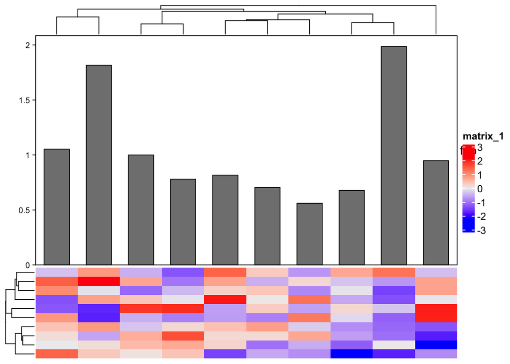

```r
library(ComplexHeatmap)

set.seed(666)
m = matrix(rnorm(100), 10)
x = abs(rnorm(10))

Heatmap(m, top_annotation = HeatmapAnnotation(foo = anno_barplot(x), height = unit(8, "cm")))
```

One natural solution is to use the `decorate_annotation()` function to add such additional graphics to the “foo” annotation. Just note `decorate_annotation()` is a post-processing function where the grey background will overwrite the bars in the annotation. Thus, we need to redraw the bars after the background grid lines are drawn.

Also note, when there is column reordering, we need to capture the new order. This information will be used for redrawing the bars.

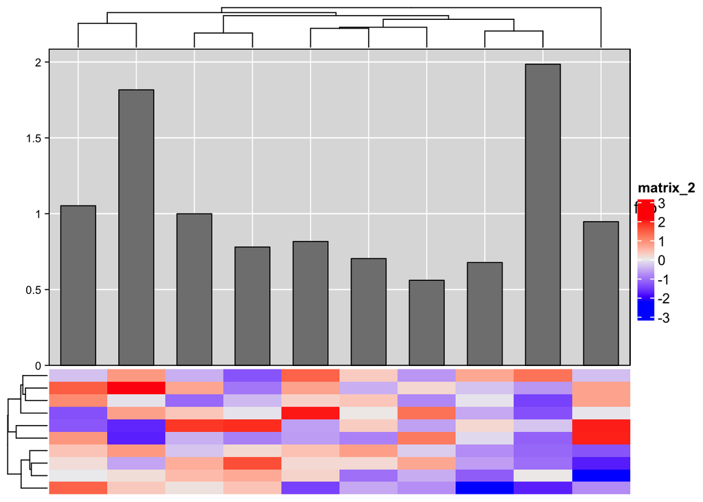

```r
ht = Heatmap(m, top_annotation = HeatmapAnnotation(foo = anno_barplot(x), height = unit(8, "cm")))
ht = draw(ht)
column_order = column_order(ht)

decorate_annotation("foo", {
    grid.rect(gp = gpar(fill = "#DDDDDD"))

    # x-breaks are always located on 1:nc where `nc` is the number of columns
    x_breaks = unit(1:10, "native")
    nx = length(x_breaks)

    # y-breaks are read from the plot
    y_breaks = unit(c(0, 0.5, 1, 1.5, 2), "native")
    ny = length(y_breaks)

    grid.segments(x_breaks, rep(unit(0, "npc"), nx), x_breaks, rep(unit(1, "npc"), nx), gp = gpar(col = "white"))
    grid.segments(rep(unit(0, "npc"), nx), y_breaks, rep(unit(1, "npc"), nx), y_breaks, gp = gpar(col = "white"))

    # draw the bars again. Note `x` should be reordered to match the matrix columns
    grid.rect(x_breaks, unit(0, "npc"), width = unit(0.6, "native"), height = unit(x[column_order], "native"),
        just = "bottom", gp = gpar(fill = "#808080", col = "black"))

    # last step is to draw the global frame of the annotation region
    grid.rect(gp = gpar(fill = NA))
})
```

In the previous code, we already know the values of x-breaks and y-breaks, which can be read from the plot and inferred from the number of columns of the matrix. Now the next question is, how to make it general where the x-breaks and y-breaks can be automatically inferred from the original matrix?

Observe the heatmap, we can see the y-breaks are the y-coordinates of the ticks or labels on the y-axis. If we can obtain these grob objects, we can obtain the coordinates of y-breaks. Similarly, the x-breaks are the x-coordinates of bars. If we can obtain such rect grobs, we can also obtain the coordinates of x-breaks.

Next let’s see whether we can obtain the axis tick grob and the bar (rect) grob from the heatmap. These two grobs are in the viewport of the “foo” annotation. The grob object can be obtained by the `grid.get()` function by providing the name of the grob. Now the problem becomes how to obtain the names of the axis grob and the rect grob within the “foo” annotation viewport?

We use the `grid.ls()` function which lists all viewports and grobs on the display list. `grid.ls()` returns a list of full viewport paths (`vpPath`), grob paths (`gPath`) if the grob is a complex one, and the name of the low-level grobs (`name`). We use `vpPath` to match the “foo” annotation viewport, use `gPath` to match the y-axis (in **ComplexHeatmap**, the axis is implemented by a `annotation_axis` complex grob), and use `name` to match the segments of y-axis.

```r
Heatmap(m, top_annotation = HeatmapAnnotation(foo = anno_barplot(x), height = unit(8, "cm")))
```

[output not shown]

```r
# grid.ls() returns a lists of all viewports and grobs, from the ROOT (the global) level
global_gl = grid.ls(viewport = TRUE, print = FALSE)
str(global_gl)
```

```
## List of 6
##  $ name   : chr [1:77] "ROOT" "global" "GRID.rect.235" "global_layout" ...
##  $ gDepth : num [1:77] 0 0 0 0 0 0 0 0 0 0 ...
##  $ vpDepth: num [1:77] 0 1 2 2 3 4 5 6 7 8 ...
##  $ gPath  : chr [1:77] "" "" "" "" ...
##  $ vpPath : chr [1:77] "" "ROOT" "ROOT::global" "ROOT::global" ...
##  $ type   : chr [1:77] "vpListing" "vpListing" "grobListing" "vpListing" ...
##  - attr(*, "class")= chr "flatGridListing"
```

The following code is put side `decorate_annotation()`. I first explain the code chunk by chunk.

The code inside `decorate_annotation()` is applied in the corresponding annotation viewport, so here `current.viewport()` returns the “foo” annotation viewport, and `vp$name` is the name of the viewport.

```r
vp = current.viewport()
```

Next we match the axis ticks. Note the last line can also be changed to `grepl("text", global_gl$name)` to match the axis labels.

```r
i = which(grepl(vp$name, global_gl$vpPath) &
          grepl("annotation_axis", global_gl$gPath) &
          grepl("segments", global_gl$name))
gb_name = unique(global_gl$name[i])
```

Once we have the name of the axis tick grob, we can retrieve the grob object with `grid.get()`.

```r
gb_tick = grid.get(gb_name)
```

`gb_tick` is a `segmentsGrob` object. The y-coordinates are in `gb_tick$y0`.

```r
y_breaks = gb_tick$y0
ny = length(y_breaks)
```

Similarly, to match the bar grobs:

```r
i = which(grepl(vp$name, global_gl$vpPath) &
          grepl("rect", global_gl$name))
i = i[1]  # there might be multiple hits, but the values of grob names are the same
gb_name = unique(global_gl$name[i])

gb_bar = grid.get(gb_name)
x_breaks = gb_bar$x
nx = length(x_breaks)
```

Now with the coordinates of x-breaks and y-breaks known, we can draw the background grid lines. We put all these code inside `decorate_annotation()`.

Note, to redraw the bars, we don’t need the column reordering any more. `gb_bar` already contains the reordered bars.

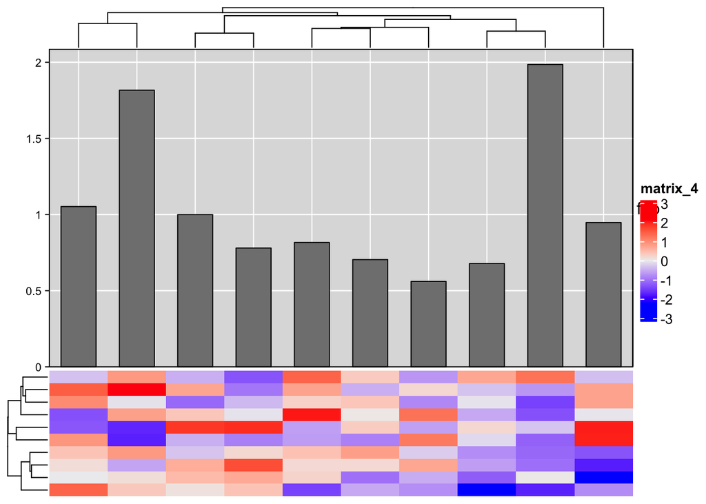

```r
Heatmap(m, top_annotation = HeatmapAnnotation(foo = anno_barplot(x), height = unit(8, "cm")))

decorate_annotation("foo", {

    global_gl = grid.ls(viewport = TRUE, print = FALSE)

    vp = current.viewport()

    i = which(grepl(vp$name, global_gl$vpPath) &
              grepl("annotation_axis", global_gl$gPath) &
              grepl("segments", global_gl$name))
    gb_name = unique(global_gl$name[i])
    gb_tick = grid.get(gb_name)
    y_breaks = gb_tick$y0
    ny = length(y_breaks)

    i = which(grepl(vp$name, global_gl$vpPath) &
              grepl("rect", global_gl$name))
    i = i[1]  # there might be multiple hits, but the values of grob names are the same
    gb_name = unique(global_gl$name[i])

    gb_bar = grid.get(gb_name)
    x_breaks = gb_bar$x
    nx = length(x_breaks)

    grid.rect(gp = gpar(fill = "#DDDDDD"))

    # now we have the x-breaks and y-breaks, we can draw the grid lines
    grid.segments(x_breaks, rep(unit(0, "npc"), nx), x_breaks, rep(unit(1, "npc"), nx), gp = gpar(col = "white"))
    grid.segments(rep(unit(0, "npc"), nx), y_breaks, rep(unit(1, "npc"), nx), y_breaks, gp = gpar(col = "white"))

    # draw the bars again
    grid.draw(gb_bar)

    # last step is to draw the global frame of the annotation region
    grid.rect(gp = gpar(fill = NA))
})
```

Let’s wrap the code into a function and test it:

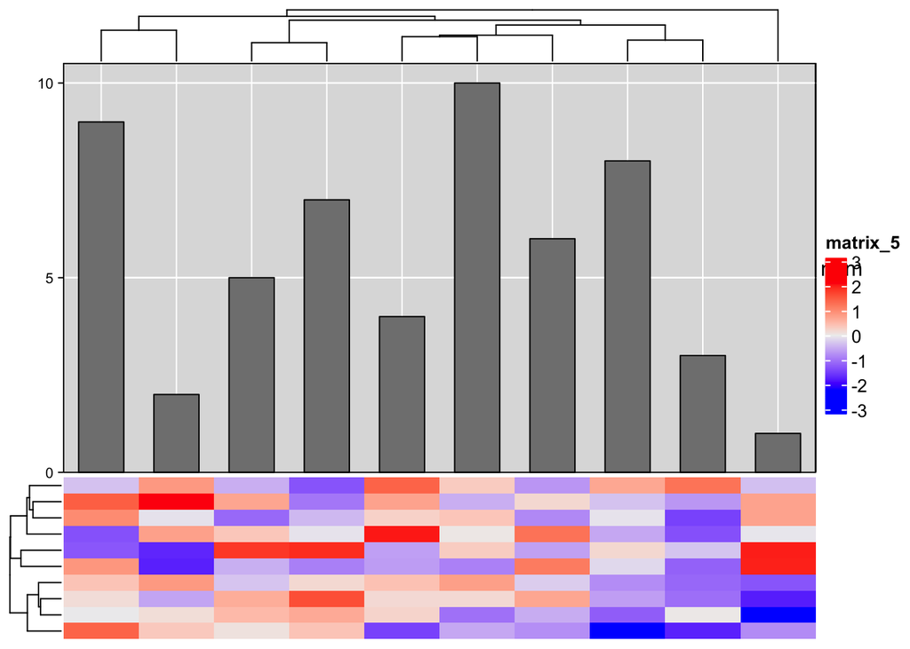

```r
add_background_to_column_barplot_annotation = function(anno_name) {
    decorate_annotation(anno_name, {

        global_gl = grid.ls(viewport = TRUE, print = FALSE)

        vp = current.viewport()

        i = which(grepl(vp$name, global_gl$vpPath) &
                  grepl("annotation_axis", global_gl$gPath) &
                  grepl("segments", global_gl$name))
        gb_name = unique(global_gl$name[i])
        gb_tick = grid.get(gb_name)
        y_breaks = gb_tick$y0
        ny = length(y_breaks)

        i = which(grepl(vp$name, global_gl$vpPath) &
                  grepl("rect", global_gl$name))
        i = i[1]  # there might be multiple hits, but the values of grob names are the same
        gb_name = unique(global_gl$name[i])

        gb_bar = grid.get(gb_name)
        x_breaks = gb_bar$x
        nx = length(x_breaks)

        grid.rect(gp = gpar(fill = "#DDDDDD"))

        # now we have the x-breaks and y-breaks, we can draw the grid lines
        grid.segments(x_breaks, rep(unit(0, "npc"), nx), x_breaks, rep(unit(1, "npc"), nx), gp = gpar(col = "white"))
        grid.segments(rep(unit(0, "npc"), nx), y_breaks, rep(unit(1, "npc"), nx), y_breaks, gp = gpar(col = "white"))

        # draw the bars again
        grid.draw(gb_bar)

        # last step is to draw the global frame of the annotation region
        grid.rect(gp = gpar(fill = NA))
    })
}

Heatmap(m, top_annotation = HeatmapAnnotation(num = anno_barplot(1:10), height = unit(8, "cm")))
add_background_to_column_barplot_annotation("num")
```

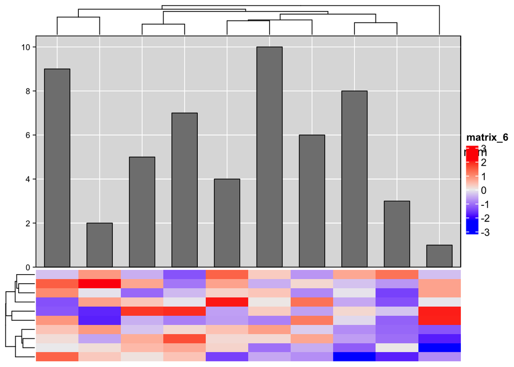

```r
Heatmap(m, top_annotation = HeatmapAnnotation(num = anno_barplot(1:10, axis_param = list(at = seq(0, 10, by = 2))),
                                              height = unit(8, "cm")))
add_background_to_column_barplot_annotation("num")
```